# Statistical Analysis of ENEM 2019 Grades in the state of Alagoas

# Classification of notes in Mesoregions

```r
meso = read_xlsx('data/mun_messorregiao.xlsx')
mean_mun=aggregate(NOTA_ENEN~NO_MUNICIPIO_RESIDENCIA,data=df,FUN=mean)
mean_mun_meso=merge(mean_mun,meso,by.x='NO_MUNICIPIO_RESIDENCIA',by.y='mun')
```

| Counties | Grade | Mesoregions |
| --- | --- | --- |
| Água Branca | 486.0334 | Sertão |
| Anadia | 498.8083 | Leste |
| Arapiraca | 520.3553 | Agreste |
| Atalaia | 480.9068 | Leste |
| Barra de Santo Antônio | 478.8730 | Leste |
| Barra de São Miguel | 500.8136 | Leste |
| Batalha | 488.2814 | Sertão |
| Belém | 476.5333 | Agreste |
| Belo Monte | 474.9516 | Sertão |
| Boca da Mata | 501.7300 | Leste |

## Distribution of grades by mesoregion

[figure not shown]

```r
grade_cut_m = cut(mean_mun_meso$NOTA_ENEN, breaks = quantile(mean_mun_meso$NOTA_ENEN),
                 include.lowest = TRUE)

quartiles_grade = table(mean_mun_meso$mesorregiao, grade_cut_m)

barplot(quartiles_grade, beside = TRUE, col = c("lightblue", 5, 'blue'),
        ylab = "Frequency", xlab = "Grades by quatiles")

legend(x = "topleft",
       legend = c("Wild", "Sertão", "East"),
       fill = c("lightblue", 5, 'blue'), xpd = TRUE)
```

# Statistical difference between the scores of the mesoregions

## Analysis of variance between the means of the mesoregions

**For this analysis, the ANOVA test was initially used**

*H0*: the means of the groups are the same

*H1*: at least one mean of the groups is different from the others

```r
res.aov=mean_mun_meso%>%
  anova_test(NOTA_ENEN ~ mesorregiao)
```

| Effect | DFn | DFd | F | p | p<.05 | ges |
| --- | --- | --- | --- | --- | --- | --- |
| mesorregiao | 2 | 99 | 1.35 | 0.264 |  | 0.027 |

As p > 0.05, the null hypothesis is not rejected, that is, there are no significant differences between the groups (p = 0.264).

**To analyze the mesoregions in pairs, the pairwise t test was used.**

*H0*: the averages of the pair are the same

*H1*: the averages of the pair are different

```r
pwc <- mean_mun_meso %>%
  pairwise_t_test(NOTA_ENEN ~ mesorregiao, p.adjust.method = "bonferroni")
```

[output not shown]

It can be seen that all p.adj were greater than 0.05, that is, **there is no statistical difference between the averages of the mesoregions.**

## Graph illustrating the variance analysis

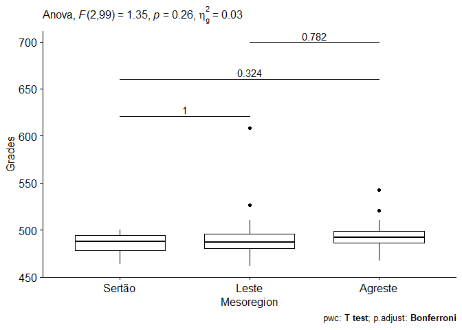

```r
pwc <- pwc %>% add_xy_position(x = "mesorregiao")
ggboxplot(mean_mun_meso, x = "mesorregiao", y = "NOTA_ENEN",
          xlab = 'Mesoregion', ylab = 'Grades') +
  stat_pvalue_manual(pwc, label = "p.adj", tip.length = 0, step.increase = 0.1,) +
  labs(
    subtitle = get_test_label(res.aov, detailed = TRUE),
    caption = get_pwc_label(pwc)
    )
```

# Correlation matrix between the scores of the 5 ENEM subjects

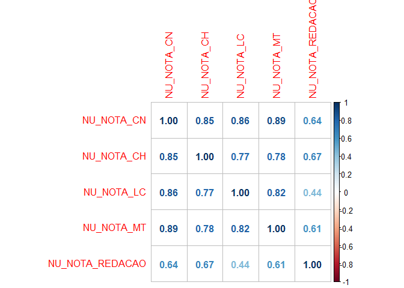

```r
grande_cn = aggregate(NU_NOTA_CN~NO_MUNICIPIO_RESIDENCIA,data=df,FUN=mean)
grades = merge(grande_cn,aggregate(NU_NOTA_CH~NO_MUNICIPIO_RESIDENCIA,data=df,
                                FUN=mean),by='NO_MUNICIPIO_RESIDENCIA')
grades = merge(grades,aggregate(NU_NOTA_LC~NO_MUNICIPIO_RESIDENCIA,data=df,
                              FUN=mean),by='NO_MUNICIPIO_RESIDENCIA')
grades = merge(grades,aggregate(NU_NOTA_MT~NO_MUNICIPIO_RESIDENCIA,data=df,
                              FUN=mean),by='NO_MUNICIPIO_RESIDENCIA')
grades = merge(grades,aggregate(NU_NOTA_REDACAO~NO_MUNICIPIO_RESIDENCIA,
                                data=df,FUN=mean),by='NO_MUNICIPIO_RESIDENCIA')


rownames(grades) = grades$NO_MUNICIPIO_RESIDENCIA
grades$NO_MUNICIPIO_RESIDENCIA = NULL

corrplot(cor(grades), method = 'number')
```

Analyzing the correlation matrix, it is possible to observe that the subjects that presented Pearson’s coefficient are Natural Sciences and Mathematics.

From this, we can perform a linear regression to identify the prediction equation.

## Regression equation

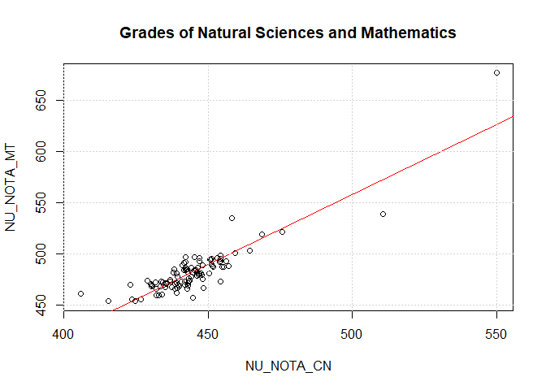

```r
cn_mt=select(grades,NU_NOTA_CN,NU_NOTA_MT)
plot(cn_mt,main='Grades of Natural Sciences and Mathematics')

regression = lm(cn_mt$NU_NOTA_MT~cn_mt$NU_NOTA_CN)

abline(regression, col='red')
grid()
```

```r
summary(regression)
```

```
##
## Call:
## lm(formula = cn_mt$NU_NOTA_MT ~ cn_mt$NU_NOTA_CN)
##
## Residuals:
##     Min      1Q  Median      3Q     Max
## -34.043  -5.736  -0.627   5.277  49.983
##
## Coefficients:
##                    Estimate Std. Error t value Pr(>|t|)
## (Intercept)      -126.21439   30.34340   -4.16 6.75e-05 ***
## cn_mt$NU_NOTA_CN    1.36864    0.06824   20.06  < 2e-16 ***
## ---
## Signif. codes:  0 '***' 0.001 '**' 0.01 '*' 0.05 '.' 0.1 ' ' 1
##
## Residual standard error: 11.1 on 100 degrees of freedom
## Multiple R-squared:  0.8009, Adjusted R-squared:  0.7989
## F-statistic: 402.3 on 1 and 100 DF,  p-value: < 2.2e-16
```

Equation defined as: 1,36*x-126,21

## Hypothesis test to validate the correlation

*H0*: there is normality in the data

*H1*: there is no normality in the data.

```r
shapiro.test(regression$residuals)
```

```
##
##  Shapiro-Wilk normality test
##
## data:  regression$residuals
## W = 0.91195, p-value = 4.452e-06
```